# Análisis de datos: Diversidad genética y estructura

Author

Sergio y Sofía

## Recursos

- [Libro de genetica del paisaje en R](https://bookdown.org/hhwagner1/LandGenCourse_book/)
- [Applied Population Genetics](http://dyerlab.github.io/applied_population_genetics/index.html)
- [Tutoriales de genética de poblaciones en R](https://popgen.nescent.org/)
- [learnPopGen](https://www.ncbi.nlm.nih.gov/pmc/articles/PMC6662327/)

## Índices básicos de diversidad genética

- Populations (stacks)
- Paquetes de R (vcfR, Adegenet, poppr, hierfstat, pegas)

### En R

Paquetes útiles para manejo de datos genéticos en R.

#### `vcfR`

Es un paquete para leer y manipular archivos vcf escrito por Brian J. Knaus. En este tutorial principalmente lo vamos a usar para leer, manipular (obtener subconjuntos, importar a otros formatos) y escribir archivos vcf.

**VCF**

El formato VCF (Variant Call Format) es un formato estandarizado para almacenar información de SNPs, indels y variaciones estructurales. La especificaciones del formato son mantenidas por el [Genomic Data Toolkit](https://www.ga4gh.org/genomic-data-toolkit/) ([formato vcf 2023](http://samtools.github.io/hts-specs/VCFv4.4.pdf)). Es uno de los formatos (input y output) comunes entre los programas de genética.

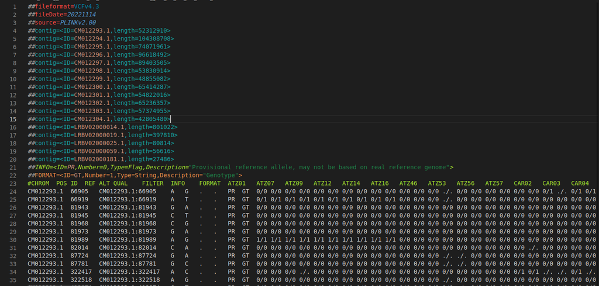

- [Introducción al paquete vcfR](https://cran.r-project.org/web/packages/vcfR/vignettes/intro_to_vcfR.html)
- [Manual de funciones vcfR (CRAN)](https://cran.r-project.org/web/packages/vcfR/vcfR.pdf)

```r
library(vcfR)
data(vcfR_example)
vcf
```

```
***** Object of Class vcfR *****
18 samples
1 CHROMs
2,533 variants
Object size: 3.2 Mb
8.497 percent missing data
*****        *****         *****
```

**Estructura**

```r
str(vcf)
```

```
Formal class 'vcfR' [package "vcfR"] with 3 slots
  ..@ meta: chr [1:29] "##fileformat=VCFv4.1" "##source=\"GATK haplotype Caller, phased with beagle4\"" "##FILTER=<ID=LowQual,Description=\"Low quality\">" "##FORMAT=<ID=AD,Number=.,Type=Integer,Description=\"Allelic depths for the ref and alt alleles in the order listed\">" ...
  ..@ fix : chr [1:2533, 1:8] "Supercontig_1.50" "Supercontig_1.50" "Supercontig_1.50" "Supercontig_1.50" ...
  .. ..- attr(*, "dimnames")=List of 2
  .. .. ..$ : NULL
  .. .. ..$ : chr [1:8] "CHROM" "POS" "ID" "REF" ...
  ..@ gt  : chr [1:2533, 1:19] "GT:AD:DP:GQ:PL" "GT:AD:DP:GQ:PL" "GT:AD:DP:GQ:PL" "GT:AD:DP:GQ:PL" ...
  .. ..- attr(*, "dimnames")=List of 2
  .. .. ..$ : NULL
  .. .. ..$ : chr [1:19] "FORMAT" "BL2009P4_us23" "DDR7602" "IN2009T1_us22" ...
```

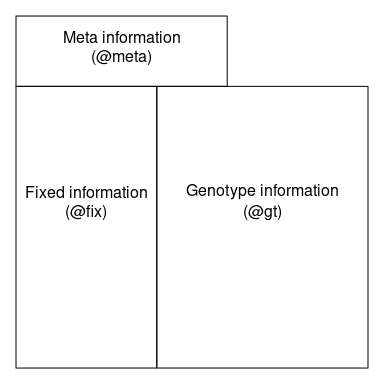

- Tutorial CRAN [VCF data](https://cran.r-project.org/web/packages/vcfR/vignettes/vcf_data.html)

**Meta:** Información acerca del archivo, versión, abreviaciones en la sección de fix y gt (INFO y FORMAT)

```r
strwrap(vcf@meta[1:7])
```

```
[1] "##fileformat=VCFv4.1"
[2] "##source=\"GATK haplotype Caller, phased with beagle4\""
[3] "##FILTER=<ID=LowQual,Description=\"Low quality\">"
[4] "##FORMAT=<ID=AD,Number=.,Type=Integer,Description=\"Allelic depths for"
[5] "the ref and alt alleles in the order listed\">"
[6] "##FORMAT=<ID=DP,Number=1,Type=Integer,Description=\"Approximate read"
[7] "depth (reads with MQ=255 or with bad mates are filtered)\">"
[8] "##FORMAT=<ID=GQ,Number=1,Type=Integer,Description=\"Genotype Quality\">"
[9] "##FORMAT=<ID=GT,Number=1,Type=String,Description=\"Genotype\">"
```

Resumen de la información en meta

```r
queryMETA(vcf)
```

```
 [1] "FILTER=ID=LowQual"
 [2] "FORMAT=ID=AD"
 [3] "FORMAT=ID=DP"
 [4] "FORMAT=ID=GQ"
 [5] "FORMAT=ID=GT"
 [6] "FORMAT=ID=PL"
 [7] "GATKCommandLine=ID=HaplotypeCaller"
 [8] "INFO=ID=AC"
 [9] "INFO=ID=AF"
[10] "INFO=ID=AN"
[11] "INFO=ID=BaseQRankSum"
[12] "INFO=ID=ClippingRankSum"
[13] "INFO=ID=DP"
[14] "INFO=ID=DS"
[15] "INFO=ID=FS"
[16] "INFO=ID=HaplotypeScore"
[17] "INFO=ID=InbreedingCoeff"
[18] "INFO=ID=MLEAC"
[19] "INFO=ID=MLEAF"
[20] "INFO=ID=MQ"
[21] "INFO=ID=MQ0"
[22] "INFO=ID=MQRankSum"
[23] "INFO=ID=QD"
[24] "INFO=ID=ReadPosRankSum"
[25] "INFO=ID=SOR"
[26] "1 contig=<IDs omitted from queryMETA"
```

Información de un elemento en particular

```r
queryMETA(vcf, element = 'DP')
```

```
[[1]]
[1] "FORMAT=ID=DP"
[2] "Number=1"
[3] "Type=Integer"
[4] "Description=Approximate read depth (reads with MQ=255 or with bad mates are filtered)"

[[2]]
[1] "INFO=ID=DP"
[2] "Number=1"
[3] "Type=Integer"
[4] "Description=Approximate read depth; some reads may have been filtered"
```

**fix:** Datos de cada variante (CHROM, POS, ID, REF, ALT, QUAL, FILTER e INFO)

```r
head(getFIX(vcf)) #getFIX suprime la columna de INFO (separada por comas)
```

```
     CHROM              POS   ID REF ALT QUAL     FILTER
[1,] "Supercontig_1.50" "2"   NA "T" "A" "44.44"  NA
[2,] "Supercontig_1.50" "246" NA "C" "G" "144.21" NA
[3,] "Supercontig_1.50" "549" NA "A" "C" "68.49"  NA
[4,] "Supercontig_1.50" "668" NA "G" "C" "108.07" NA
[5,] "Supercontig_1.50" "765" NA "A" "C" "92.78"  NA
[6,] "Supercontig_1.50" "780" NA "G" "T" "58.38"  NA
```

**gt**: Información de cada variante para cada muestra (separada por :). La columna de formato indica el orden de los datos

```r
vcf@gt[1:6, 1:4]
```

```
     FORMAT           BL2009P4_us23               DDR7602
[1,] "GT:AD:DP:GQ:PL" "0|0:62,0:62:99:0,190,2835" "0|0:12,0:12:39:0,39,585"
[2,] "GT:AD:DP:GQ:PL" "1|0:5,5:10:99:111,0,114"   NA
[3,] "GT:AD:DP:GQ:PL" NA                          NA
[4,] "GT:AD:DP:GQ:PL" "0|0:1,0:1:3:0,3,44"        NA
[5,] "GT:AD:DP:GQ:PL" "0|0:2,0:2:6:0,6,49"        "0|0:1,0:1:3:0,3,34"
[6,] "GT:AD:DP:GQ:PL" "0|0:2,0:2:6:0,6,49"        "0|0:1,0:1:3:0,3,34"
     IN2009T1_us22
[1,] "0|0:37,0:37:99:0,114,1709"
[2,] "0|1:2,1:3:16:16,0,48"
[3,] "0|0:2,0:2:6:0,6,51"
[4,] "1|1:0,1:1:3:25,3,0"
[5,] "0|0:1,0:1:3:0,3,31"
[6,] "0|0:3,0:3:9:0,9,85"
```

**Subconjuntos**

```r
vcf[1:3,]
```

```
***** Object of Class vcfR *****
18 samples
1 CHROMs
3 variants
Object size: 0 Mb
51.85 percent missing data
*****        *****         *****
```

```r
vcf[,1:3]
```

```
***** Object of Class vcfR *****
2 samples
1 CHROMs
2,533 variants
Object size: 1.4 Mb
4.362 percent missing data
*****        *****         *****
```

**Convertir a formatos comunes**

```r
data = vcfR2genlight(vcf)
```

Funciones útiles cambio de formato:

*adegenet*

- `vcfR2genind`
- `vcfR2genlight`

*tidy*

- `vcfR2tidy`

**Ejercicio**

**Ejercicio**

1. Utiliza la función `read.vcfR` para leer el archivo vcf de prueba.
2. Examina los slots del objeto
3. Convierte el objeto a formato `genind`

**Respuesta**

```r
# Leer archivo vcf
data = read.vcfR("../inputs/vcf/archivo.vcf")

# Convertir a formato genind
genind = vcfR2genind(data)
```

#### `adegenet`

- [Tutorial adegenet 1.2-7](https://adegenet.r-forge.r-project.org/files/tutorial.pdf)

Hay 3 clases de objetos principales:

- genind
- genpop
- genlight

Otras funciones para importar datos *adegenet*

- `df2genind`
- `genind2hierfstat`

**genind**

Objeto S4 con diferentes slots que se ingresan usando @:

- `@tab`: matriz de genotipos
- `@loc.n.all`: número de alelos por locus
- `@loc.fac`: factor de loci (nombres de loci)
- `@all.names`: alelos por locus (ej. loci bialélicos tienen alelo 0 y 1)
- `@ploidy`: ploidia
- `@type`: tipo de marcador
- `@call`: comando

Opcionalmente

- `@pop`: factor que indica la población a la que pertenece cada individuo
- `@strata`: factor con niveles jerárquicos a los que pertenecen los individuos (ej. población, región)
- `@other`: una lista con: xy

```r
library(adegenet)

data(nancycats)
```

**genpop**

A diferencia de `genind`genpop almacena los conteos por locus de cada población.

- `@tab`: matriz de alelos
- `@loc.n.all`: número de alelos por locus (range: 8-18)
- `@loc.fac`: factor de loci (nombres de loci)
- `@all.names`: lista de alelos por locus
- `@ploidy`: ploidia
- `@type`: tipo de marcador
- `@call`: comando
- `@other`: una lista con: xy

```r
genind2genpop(nancycats)
```

```
 Converting data from a genind to a genpop object...

...done.
```

```
/// GENPOP OBJECT /////////

 // 17 populations; 9 loci; 108 alleles; size: 31 Kb

 // Basic content
   @tab:  17 x 108 matrix of allele counts
   @loc.n.all: number of alleles per locus (range: 8-18)
   @loc.fac: locus factor for the 108 columns of @tab
   @all.names: list of allele names for each locus
   @ploidy: ploidy of each individual  (range: 2-2)
   @type:  codom
   @call: genind2genpop(x = nancycats)

 // Optional content
   @other: a list containing: xy
```

**genlight**

Objeto que puede guardar la información genotípica de una manera más eficiente que los dos anteriores.

- `@ind.names`: número de individuos
- `@loc.names`: número de loci
- `@chromosome`: vector de cromosomas
- `@position`: vector de posiciones
- `@other`: metadatos

```r
data
```

```
 /// GENLIGHT OBJECT /////////

 // 18 genotypes,  2,497 binary SNPs, size: 290 Kb
 3835 (8.53 %) missing data

 // Basic content
   @gen: list of 18 SNPbin

 // Optional content
   @ind.names:  18 individual labels
   @loc.names:  2497 locus labels
   @chromosome: factor storing chromosomes of the SNPs
   @position: integer storing positions of the SNPs
   @other: a list containing: elements without names
```

**Filtros**

- El elemento principal de los tres objetos anteriores es la matriz de genotipos, por lo tanto, se pueden filtrar como data frame objeto[individuos, loci].

```r
data[1:3,1:10]
```

```
 /// GENLIGHT OBJECT /////////

 // 3 genotypes,  10 binary SNPs, size: 8.4 Kb
 5 (16.67 %) missing data

 // Basic content
   @gen: list of 3 SNPbin

 // Optional content
   @ind.names:  3 individual labels
   @loc.names:  10 locus labels
   @chromosome: factor storing chromosomes of the SNPs
   @position: integer storing positions of the SNPs
   @other: a list containing: elements without names
```

- También se pueden filtrar utilizando la información de los otros slots

```r
library(tidyverse)

set.seed(10)
sample(indNames(nancycats),10)
```

```
 [1] "N281" "N273" "N61"  "N96"  "N235" "N198" "N59"  "N197" "N166" "N256"
```

```r
set.seed(10)
t = nancycats[which(rownames(nancycats@tab) %in% sample(indNames(nancycats),10)),]
t@tab[,1:5]
```

```
     fca8.117 fca8.119 fca8.121 fca8.123 fca8.127
N59         0        0        0        0        0
N61         0        0        0        0        0
N96         0        0        0        0        0
N273        0        0        0        1        0
N166        0        0        0        0        0
N197       NA       NA       NA       NA       NA
N198       NA       NA       NA       NA       NA
N235        0        0        0        0        0
N256        0        0        0        0        0
N281        0        0        0        0        0
```

**Resumenes**

```r
summary(nancycats)
```

```
// Number of individuals: 237
// Group sizes: 10 22 12 23 15 11 14 10 9 11 20 14 13 17 11 12 13
// Number of alleles per locus: 16 11 10 9 12 8 12 12 18
// Number of alleles per group: 36 53 50 67 48 56 42 54 43 46 70 52 44 61 42 40 35
// Percentage of missing data: 2.34 %
// Observed heterozygosity: 0.67 0.67 0.68 0.71 0.63 0.57 0.65 0.62 0.45
// Expected heterozygosity: 0.87 0.79 0.8 0.76 0.87 0.69 0.82 0.76 0.61
```

#### `hierfstat`

```r
library(hierfstat)

data = genind2hierfstat(nancycats)

basic_stats = basic.stats(data)
```

Resultados por locus

| Ho | Hs | Ht | Dst | Htp | Dstp | Fst | Fstp | Fis | Dest |
| --- | --- | --- | --- | --- | --- | --- | --- | --- | --- |
| 0.6670 | 0.7790 | 0.8619 | 0.0829 | 0.8671 | 0.0881 | 0.0962 | 0.1016 | 0.1438 | 0.3987 |
| 0.6838 | 0.7439 | 0.7994 | 0.0555 | 0.8029 | 0.0589 | 0.0694 | 0.0734 | 0.0809 | 0.2302 |
| 0.6814 | 0.7442 | 0.7937 | 0.0495 | 0.7968 | 0.0526 | 0.0623 | 0.0660 | 0.0844 | 0.2054 |
| 0.7100 | 0.7085 | 0.7642 | 0.0557 | 0.7679 | 0.0594 | 0.0729 | 0.0774 | -0.0021 | 0.2039 |
| 0.6295 | 0.7828 | 0.8659 | 0.0831 | 0.8711 | 0.0883 | 0.0960 | 0.1014 | 0.1958 | 0.4067 |
| 0.5773 | 0.6339 | 0.6773 | 0.0434 | 0.6801 | 0.0462 | 0.0641 | 0.0679 | 0.0893 | 0.1261 |
| 0.6454 | 0.7408 | 0.8144 | 0.0736 | 0.8190 | 0.0782 | 0.0904 | 0.0955 | 0.1287 | 0.3017 |
| 0.6259 | 0.6747 | 0.7657 | 0.0910 | 0.7714 | 0.0967 | 0.1189 | 0.1254 | 0.0723 | 0.2973 |
| 0.4485 | 0.5671 | 0.6027 | 0.0356 | 0.6049 | 0.0379 | 0.0591 | 0.0626 | 0.2091 | 0.0874 |

Resultados generales

| Índice | Valor |
| --- | --- |
| Ho | 0.6299 |
| Hs | 0.7083 |
| Ht | 0.7717 |
| Dst | 0.0634 |
| Htp | 0.7757 |
| Dstp | 0.0674 |
| Fst | 0.0821 |
| Fstp | 0.0869 |
| Fis | 0.1108 |
| Dest | 0.2310 |

## ADMIXTURE

- Como correr PGDSpider (manipulación de formatos)
- Correr ADMIXTURE

## PCA

- Adegenet